# EDA zbioru ‘Heart Disease UCI Dataset’

Mateusz Romek

2024-11-25

# 1. Wstęp - cel pracy

Celem pracy jest analiza zbioru danych pacjentów z chorobami serca. Przyjrzę się różnym czynnikom które mogą mieć wpływ na chorobę i będę analizować zależności między nimi. Dane użyte w analizie pochodzą ze strony Kaggle, a zbiór to “Heart Disease UCI Dataset”. Jednym z głównych zadań tego zbioru danych jest przewidzenie na podstawie danych cech pacjenta, czy dana osoba ma chorobę serca, czy nie. W związku z tym odpowiem na poniższe pytania:

- Czy występuje zależność pomiędzy wiekiem pacjenta, a występowaniem choroby?
- Czy płeć pacjenta ma znaczenie?
- Jaki jest wpływ cholesterolu na chorobę?
- Co można wywnioskować z wyników ciśnienia spoczynkowego?
- Jaki typ bólu klatki piersiowej może sugerować problemy z sercem?
- Czy wysoki poziom cukru ma związek z chorobami serca?
- Jak wyniki depresji odcinka ST rzutowały na liczbę chorych?
- Jaka grupa badanych była najbardziej narażona?
- Jak chorzy poradzili sobie z testem wysiłkowym?
- Co pokazują nam wyniki EKG?
- Który region spośród badanych miał najwięcej przypadków z bardziej rozwiniętym stadium choroby?

Odpowiadając na te pytania scharakteryzuje potencjalne oznaki, które mogą sugerować problemy z sercem.

## a) Użyte biblioteki

```r
library(tidyverse)
library(readr)
library(ggplot2)
library(dplyr)
library(gridExtra)
library(corrplot)
library(RColorBrewer)
```

## b) Wczytanie danych

Wczytanie pliku csv z danymi:

```r
dane <- read.csv("C:/Users/PC/Desktop/chroby_serca_uci.csv")
```

## c) Przygotowanie danych do analizy

W zmiennych “chol” i “trestbps” występują nieporządane wartości 0

```r
sum(dane$chol == 0, na.rm = TRUE)
```

```
## [1] 172
```

```r
sum(dane$trestbps == 0, na.rm = TRUE)
```

```
## [1] 1
```

Liczenie średniej dla tych zmiennych z pominięciem wartości 0 i zastąpienie 0 średnią tych zmiennych

```r
srednia_chol <- mean(dane$chol[dane$chol != 0], na.rm = TRUE)
srednia_cisnienie <- mean(dane$trestbps[dane$trestbps != 0], na.rm = TRUE)

dane$chol <- ifelse(dane$chol == 0, srednia_chol, dane$chol)
dane$trestbps <- ifelse(dane$trestbps == 0, srednia_cisnienie, dane$trestbps)

sum(dane$chol == 0, na.rm = TRUE)
```

```
## [1] 0
```

```r
sum(dane$trestbps == 0, na.rm = TRUE)
```

```
## [1] 0
```

## d) Sprawdzanie, czy występują braki w danych

W niektórych zmiennych konieczne jest zastąpienie pustych pól na wartości NA

```r
dane$slope[dane$slope == ""] <- NA
dane$thal[dane$thal == ""] <- NA
dane$restecg[dane$restecg == ""] <- NA
liczba_brakow <- colSums(is.na(dane))
liczba_brakow
```

```
##       id      age      sex  dataset       cp trestbps     chol      fbs
##        0        0        0        0        0       59       30       90
##  restecg   thalch    exang  oldpeak    slope       ca     thal      num
##        2       55       55       62      309      611      486        0
```

Widoczne są spore braki w niektórych zmiennych

## e) Zastąpienie braków medianą lub najczęściej występującą wartością (w zależności od typu zmiennej):

```r
dane$trestbps[is.na(dane$trestbps)] <- median(dane$trestbps, na.rm = TRUE)
dane$chol[is.na(dane$chol)] <- median(dane$chol, na.rm = TRUE)
dane$fbs[is.na(dane$fbs)] <- names(which.max(table(dane$fbs)))
dane$thalch[is.na(dane$thalch)] <- median(dane$thalch, na.rm = TRUE)
dane$exang[is.na(dane$exang)] <- names(which.max(table(dane$exang)))
dane$restecg[is.na(dane$restecg)] <- names(which.max(table(dane$restecg)))
dane$oldpeak[is.na(dane$oldpeak)] <- median(dane$oldpeak, na.rm = TRUE)
dane <- dane %>% select(-ca)
dane <- dane %>% select(-slope)
dane <- dane %>% select(-thal)
```

Usunięcie wybranych zmiennych, ze względu na duży brak w zmiennej ca (ok.66%) i w zmiennej slope (ok.34%), oraz w zmiennej thal (ok.53%)

Sprawdzenie czyszczenia danych:

```r
colSums(is.na(dane))
```

```
##       id      age      sex  dataset       cp trestbps     chol      fbs
##        0        0        0        0        0        0        0        0
##  restecg   thalch    exang  oldpeak      num
##        0        0        0        0        0
```

Dane są oczyszczone

## f) Usunięcie wartości odstających.

Na całym zbiorze danych zastosuję zasadę 3 sigm w celu usunięcia wartości odstających, ponieważ wartości odstające mogą zaburzać analizę.

```r
usun_odstajace <- function(df) {
  for (col in colnames(df)) {
    if (is.numeric(df[[col]])) {
      srednia_war <- mean(df[[col]], na.rm = TRUE)
      sd_war <- sd(df[[col]], na.rm = TRUE)

      dolny_limit <- srednia_war - 3 * sd_war
      gorny_limit <- srednia_war + 3 * sd_war

      df <- df[df[[col]] >= dolny_limit & df[[col]] <= gorny_limit, ]
    }
  }
  return(df)
}

dane_bez_odstajacych <- usun_odstajace(dane)

nrow(dane_bez_odstajacych)
```

```
## [1] 891
```

```r
dane<-dane_bez_odstajacych
```

Zostaje 891 obserwacji, dane są gotowe do analizy

## g) Struktura i podgląd danych:

```r
str(dane)
```

```
## 'data.frame':    891 obs. of  13 variables:
##  $ id      : int  1 2 3 4 5 6 7 8 9 10 ...
##  $ age     : int  63 67 67 37 41 56 62 57 63 53 ...
##  $ sex     : chr  "Male" "Male" "Male" "Male" ...
##  $ dataset : chr  "Cleveland" "Cleveland" "Cleveland" "Cleveland" ...
##  $ cp      : chr  "typical angina" "asymptomatic" "asymptomatic" "non-anginal" ...
##  $ trestbps: num  145 160 120 130 130 120 140 120 130 140 ...
##  $ chol    : num  233 286 229 250 204 236 268 354 254 203 ...
##  $ fbs     : chr  "TRUE" "FALSE" "FALSE" "FALSE" ...
##  $ restecg : chr  "lv hypertrophy" "lv hypertrophy" "lv hypertrophy" "normal" ...
##  $ thalch  : int  150 108 129 187 172 178 160 163 147 155 ...
##  $ exang   : chr  "FALSE" "TRUE" "TRUE" "FALSE" ...
##  $ oldpeak : num  2.3 1.5 2.6 3.5 1.4 0.8 3.6 0.6 1.4 3.1 ...
##  $ num     : int  0 2 1 0 0 0 3 0 2 1 ...
```

```r
head(dane, 5)
```

```
##   id age    sex   dataset              cp trestbps chol   fbs        restecg
## 1  1  63   Male Cleveland  typical angina      145  233  TRUE lv hypertrophy
## 2  2  67   Male Cleveland    asymptomatic      160  286 FALSE lv hypertrophy
## 3  3  67   Male Cleveland    asymptomatic      120  229 FALSE lv hypertrophy
## 4  4  37   Male Cleveland     non-anginal      130  250 FALSE         normal
## 5  5  41 Female Cleveland atypical angina      130  204 FALSE lv hypertrophy
##   thalch exang oldpeak num
## 1    150 FALSE     2.3   0
## 2    108  TRUE     1.5   2
## 3    129  TRUE     2.6   1
## 4    187 FALSE     3.5   0
## 5    172 FALSE     1.4   0
```

## h) Podstawowe statystyki danych:

```r
summary(dane)
```

```
##        id             age           sex              dataset
##  Min.   :  1.0   Min.   :28.0   Length:891         Length:891
##  1st Qu.:233.5   1st Qu.:47.0   Class :character   Class :character
##  Median :460.0   Median :54.0   Mode  :character   Mode  :character
##  Mean   :461.9   Mean   :53.5
##  3rd Qu.:694.5   3rd Qu.:60.0
##  Max.   :920.0   Max.   :77.0
##       cp               trestbps          chol           fbs
##  Length:891         Min.   : 80.0   Min.   :100.0   Length:891
##  Class :character   1st Qu.:120.0   1st Qu.:216.5   Class :character
##  Mode  :character   Median :130.0   Median :246.8   Mode  :character
##                     Mean   :131.6   Mean   :243.6
##                     3rd Qu.:140.0   3rd Qu.:264.0
##                     Max.   :185.0   Max.   :394.0
##    restecg              thalch         exang              oldpeak
##  Length:891         Min.   : 63.0   Length:891         Min.   :-2.0000
##  Class :character   1st Qu.:120.0   Class :character   1st Qu.: 0.0000
##  Mode  :character   Median :140.0   Mode  :character   Median : 0.5000
##                     Mean   :137.8                      Mean   : 0.8257
##                     3rd Qu.:156.0                      3rd Qu.: 1.5000
##                     Max.   :202.0                      Max.   : 4.0000
##       num
##  Min.   :0.0000
##  1st Qu.:0.0000
##  Median :1.0000
##  Mean   :0.9787
##  3rd Qu.:2.0000
##  Max.   :4.0000
```

## i) Zaprezentowwanie rozkładów i wyciągnięcie wstępnych wniosków:

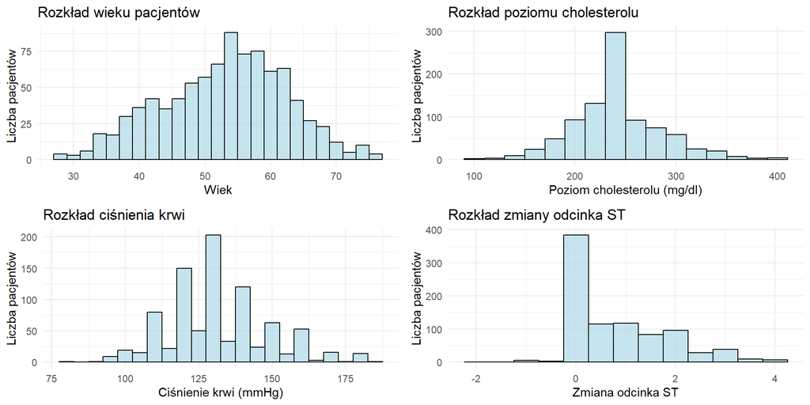

```r
p1 <- ggplot(dane, aes(x = age)) +
  geom_histogram(binwidth = 2, fill = "lightblue", color = "black", alpha = 0.7) +
  labs(title = "Rozkład wieku pacjentów", x = "Wiek", y = "Liczba pacjentów") +
  theme_minimal()

p2 <- ggplot(dane, aes(x = chol)) +
  geom_histogram(binwidth = 20, fill = "lightblue", color = "black", alpha = 0.7) +
  labs(title = "Rozkład poziomu cholesterolu", x = "Poziom cholesterolu (mg/dl)", y = "Liczba pacjentów") +
  theme_minimal()

p3 <- ggplot(dane, aes(x = trestbps)) +
  geom_histogram(binwidth = 5, fill = "lightblue", color = "black", alpha = 0.7) +
  labs(title = "Rozkład ciśnienia krwi", x = "Ciśnienie krwi (mmHg)", y = "Liczba pacjentów") +
  theme_minimal()

p4 <- ggplot(dane, aes(x = oldpeak)) +
  geom_histogram(binwidth = 0.5, fill = "lightblue", color = "black", alpha = 0.7) +
  labs(title = "Rozkład zmiany odcinka ST", x = "Zmiana odcinka ST", y = "Liczba pacjentów") +
  theme_minimal()

grid.arrange(p1, p2, p3, p4, ncol = 2)
```

**Wnioski:**

- wiek pacjentów ma rozkład zbliżony do normalnego, z największą liczbą pacjentów w przedziale 50–60 lat
- większość pacjentów ma poziom cholesterolu w okolicach 250 mg/dl, przypomina rozkład normalny
- najwięcej pacjentów ma ciśnienie krwi w przedziale około 130 mmHg, co jest zgodne z typowym zakresem normy, ale rozciąga się w obie strony, co może oznaczać obecność pacjentów zarówno z hipotensją (ciśnienie poniżej 90 mmHg), jak i nadciśnieniem
- Większość pacjentów ma zmiany odcinka ST bliskie 0, co jest zgodne z normą dla zdrowego serca, ale obserwuje się również sporą liczbę pacjentów z podwyższonymi odcinka ST, co może wskazywać na obecność problemów sercowych

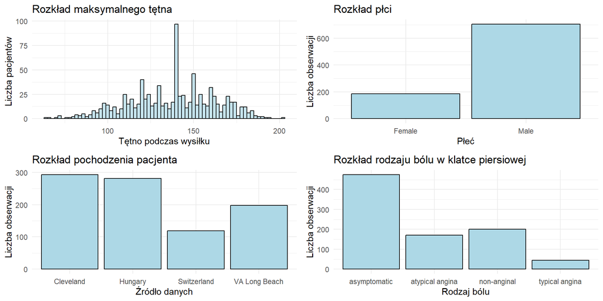

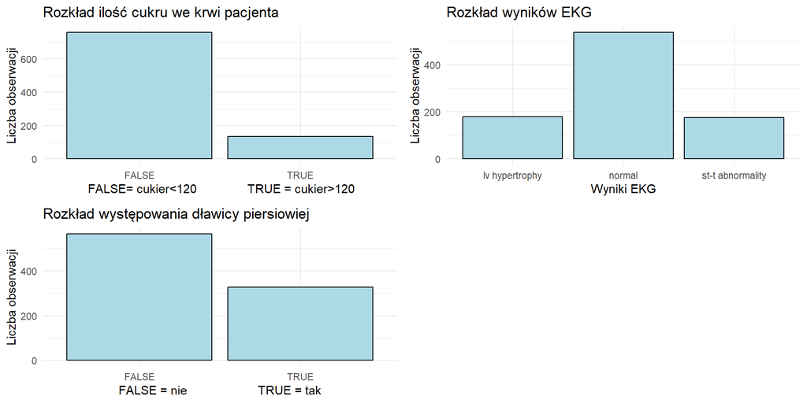

**Wnioski:**

- większość pacjentów ma poziom cukru we krwi poniżej 120 mg/dl, niewielka część pacjentów ma podwyższony poziom cukru co może wskazywać na ograniczoną liczbę przypadków cukrzycy w badanej populacji lub jej umiarkowane nasilenie
- u większości pacjentów wyniki EKG są normalne, spora grupa wykazuje nieprawidłowości ST-T co może świadczyć o problemach z przepływem krwi w mięśniu sercowym
- większość pacjentów nie doświadcza dławicy piersiowiej przy wysiłku fizycznym ale jest też duża grupa, która zgłasza ten problem co może wskazywać na obecność problemów sercowo-naczyniowych

## j) Znaczenie zmiennych:

1. **`id`** - Unikalny identyfikator dla każdego pacjenta.
2. **`age`** - Wiek pacjenta w latach.
3. **`sex`** - Płeć pacjenta:
   - `Male` - Mężczyzna
   - `Female` - Kobieta
4. **`dataset`** - Pochodzenie pacjenta (miejsce nauki).
5. **`cp`** - Określa typ bólu w klatce piersiowej:
   - `typical angina` - Typowa dławica piersiowa
   - `asymptomatic` - Bezobjawowy
   - `non-anginal` - Bez dławicy piersiowej
   - `atypical angina` - Atypowa dławica piersiowa
6. **`trestbps`** - Spoczynkowe ciśnienie krwi pacjenta (w mm Hg).
7. **`chol`** - Poziom cholesterolu całkowitego w surowicy pacjenta (w mg/dl).
8. **`fbs`** - Informacja, czy poziom cukru we krwi na czczo pacjenta jest większy niż 120 mg/dl:
   - `TRUE` - Jest większy niż 120 mg/dl
   - `FALSE` - Jest mniejszy niż 120 mg/dl
9. **`restecg`** - Wynik elektrokardiogramu (EKG) wykonanego w spoczynku:
   - `normal` - Normalny wynik
   - `lv hypertrophy` - Przerost lewej komory serca
   - `abnormal` - Nieprawidłowy wynik
10. **`thalch`** - Maksymalne tętno, jakie pacjent osiągnął podczas testu wysiłkowego. Wysokie tętno może wskazywać na dobrą kondycję serca, podczas gdy zbyt niskie może sugerować problemy.
11. **`exang`** - Określa, czy pacjent doświadcza dławicy piersiowej wywowałanej wysiłkiem fizycznym:
    - `TRUE` - Tak, pacjent doświadcza anginy
    - `FALSE` - Nie, pacjent nie doświadcza anginy
12. **`oldpeak`** - Obniżenie odcinka ST wywołane wysiłkiem fizycznym w stosunku do odpoczynku, wyrażone w milimetrach (mm)
13. **`ca`** - Liczba głównych naczyń (0-3) zabarwionych fluoroskopowo
14. **`thal`** - Określa wyniki testu talasemicznego, który wykrywa obecność zaburzeń w budowie krwi, zwłaszcza w przypadku anemii:
    - `normal` - Normalny wynik
    - `reversable defect` - Defekt odwracalny
    - `fixed defect` - Defekt stały
15. **`slope`** - Określa, jak nachylony jest szczyt odcinka ST na EKG podczas wysiłku:
    - `upsloping` – Nachylenie w górę
    - `flat` – Płaski szczyt
    - `downsloping` – Nachylenie w dół
16. **`num`** - Zmienna wynikowa, która określa obecność lub brak choroby serca:
    - `0` – Brak choroby serca
    - `1, 2, 3, 4` – Obecność choroby serca w różnym stopniu

## k) Macierz korelacji pomiędzy wybranymi zmiennymi ciągłymi:

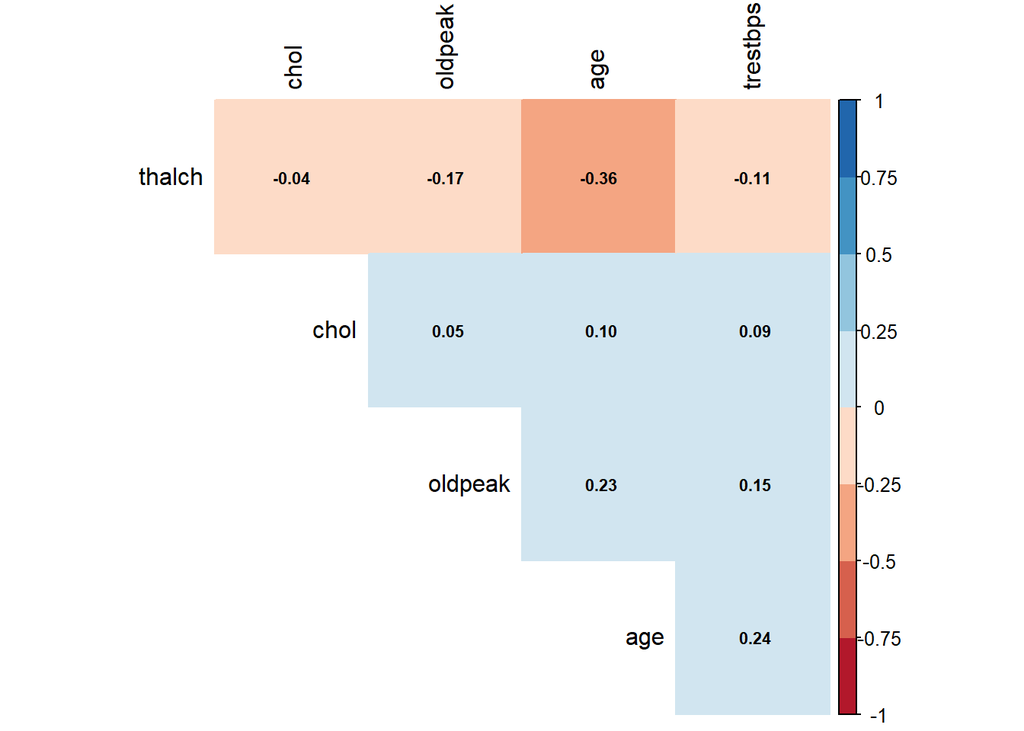

```r
dane_num <- dane[, c("age", "trestbps", "chol", "thalch", "oldpeak")]

cor_matrix <- cor(dane_num, use = "complete.obs")

corrplot(cor_matrix,
         method = "color",
         type = "upper",
         order = "hclust",
         col = brewer.pal(n = 8, name = "RdBu"),
         tl.col = "black",
         addCoef.col = "black",
         number.cex = 0.7,
         diag = FALSE)
```

# 2. Czy istnieje zależność pomiędzy wiekem pacjenta a obecnością choroby serca?

## a) Grupowanie danych, aby każda kombinacja wieku i stopnia choroby była traktowana osobno i przedstawienie ich na wykresie

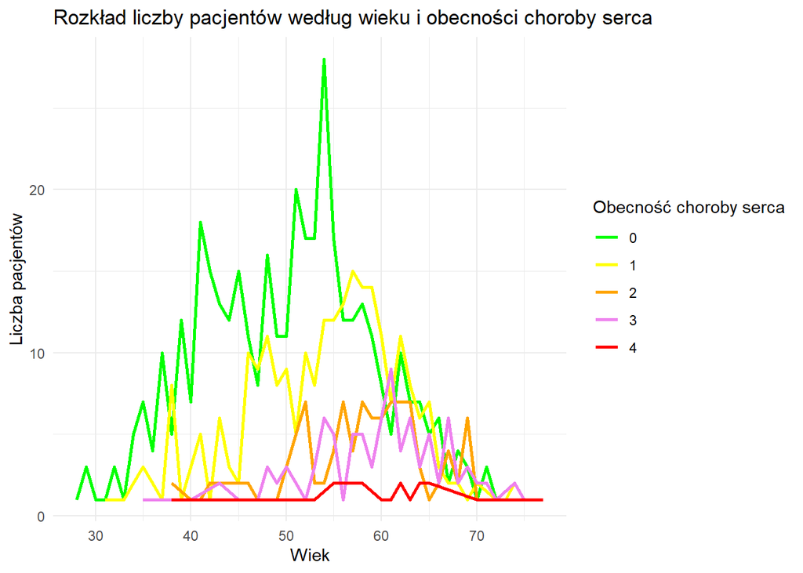

```r
dane_grupowane <- dane %>%
  group_by(age, num) %>%
  summarise(liczba = n(), .groups = 'drop')

ggplot(dane_grupowane, aes(x = age, y = liczba, group = factor(num), color = factor(num))) +
  geom_line(linewidth = 1) +
  scale_color_manual(values = c("green", "yellow", "orange", "violet", "red")) +
  labs(title = "Rozkład liczby pacjentów według wieku i obecności choroby serca",
       x = "Wiek",
       y = "Liczba pacjentów",
       color = "Obecność choroby serca") +
  theme_minimal()
```

Z wykresu można odczytać że po około 55 roku życia ilość zdrowych znacząco się kurczy, a ilość chorych wzrasta.

## b) Obliczanie średniego wieku dla każdego stopnia zaawansowania choroby

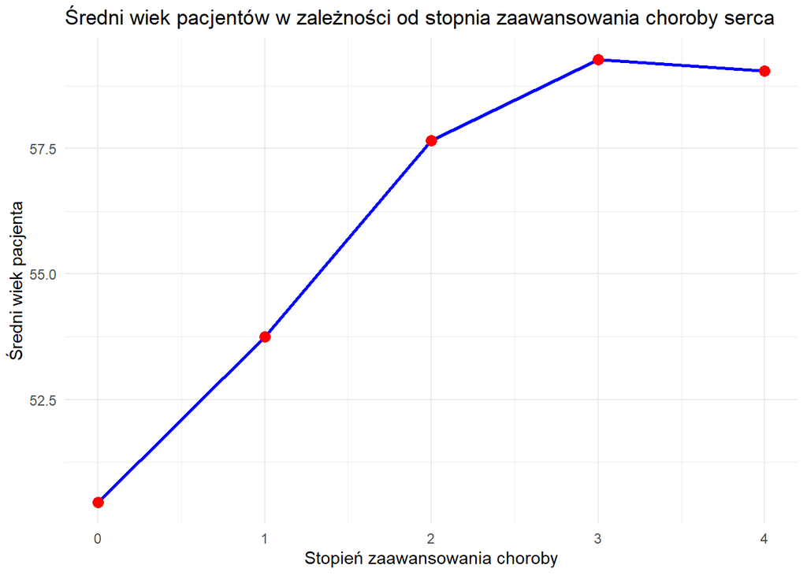

```r
dane_podsumowanie <- dane %>%
  group_by(num) %>%
  summarise(sredni_wiek = mean(age))

ggplot(dane_podsumowanie, aes(x = num, y = sredni_wiek, group = 1)) +
  geom_line(color = "blue", size = 1) +
  geom_point(color = "red", size = 3) +
  labs(title = "Średni wiek pacjentów w zależności od stopnia zaawansowania choroby serca",
       x = "Stopień zaawansowania choroby",
       y = "Średni wiek pacjenta") +
  theme_minimal()
```

Wykres pokazuje, że wraz ze wzrostem wieku wzrasta również stopień zaawansowanie choroby serca (z wyjątkiem 3 i 4 stadium, tutaj średnia wieku przyjmuje podobną wartość).

# 3. Która grupa wiekowa jest najbardziej narażona?

Dzielenie wieku na pięć grup wiekowych:

```r
dane <- dane %>%
  mutate(klasa_wieku = case_when(
    age < 30 ~ "Młodszy",
    age >= 30 & age <= 40 ~ "Dorosły młodszy",
    age >= 41 & age <= 50 ~ "Średni wiek",
    age >= 51 & age <= 60 ~ "Dorosły starszy",
    age > 60 ~ "Senior"
  ))
```

Wykaz obserwacji w różnych stadiach choroby:

```r
table(dane$klasa_wieku, dane$num)
```

```
##
##                     0   1   2   3   4
##   Dorosły młodszy  56  23   3   3   1
##   Dorosły starszy 155 114  50  37  11
##   Młodszy           4   0   0   0   0
##   Senior           58  54  42  49  11
##   Średni wiek     130  64  12  12   2
```

## a) Obliczenie odsetka chorych z podziałem na płeć:

```r
odsetek_chorych <- dane %>%
  group_by(klasa_wieku, sex) %>%
  summarise(
    total = n(),
    z_choroba = sum(num > 0),
    procent = (z_choroba / total) * 100,
    .groups = "drop"
  )

odsetek_chorych
```

```
## # A tibble: 9 × 5
##   klasa_wieku     sex    total z_choroba procent
##   <chr>           <chr>  <int>     <int>   <dbl>
## 1 Dorosły młodszy Female    20         4    20
## 2 Dorosły młodszy Male      66        26    39.4
## 3 Dorosły starszy Female    67        18    26.9
## 4 Dorosły starszy Male     300       194    64.7
## 5 Młodszy         Male       4         0     0
## 6 Senior          Female    40        16    40
## 7 Senior          Male     174       140    80.5
## 8 Średni wiek     Female    59         7    11.9
## 9 Średni wiek     Male     161        83    51.6
```

## b) Znalezienie najbardziej narażonej grupy wiekowej:

```r
najbardziej_narażona_grupa <- odsetek_chorych %>%
  group_by(sex) %>%
  filter(procent == max(procent))

najbardziej_narażona_grupa
```

```
## # A tibble: 2 × 5
## # Groups:   sex [2]
##   klasa_wieku sex    total z_choroba procent
##   <chr>       <chr>  <int>     <int>   <dbl>
## 1 Senior      Female    40        16    40
## 2 Senior      Male     174       140    80.5
```

U mężczyzn powyżej 60 roku życia choroba występuje w 80,5% przypadkach, jest to grupa z najwyższym odsetkiem. Dla kobiet powyżej 60 roku życia choroba występuje w 40% przypadkach.

# 4. Czy mężczyźni są istotnie bardziej narażeni niż kobiety?

Sprawdzam, ile jest męzczyzn, a ile kobiet

```r
table(dane$sex)
```

```
##
## Female   Male
##    186    705
```

Dodanie zmiennej “choroba”, która dzieli pacjentów na “Zdrowy” i “Chory”

```r
dane$choroba <- ifelse(dane$num == 0, "Zdrowy", "Chory")
```

Utworzenie tabeli pomiędzy płcią a zmnienną “choroba”

```r
tabela <- table(dane$sex, dane$choroba)
tabela
```

```
##
##          Chory Zdrowy
##   Female    45    141
##   Male     443    262
```

Obliczenie procentu zdrowych i chorych dla każdej płci:

```r
procenty <- prop.table(tabela, margin = 1) * 100

wynik <- data.frame(
  Płeć = rownames(procenty),
  Procent_Zdrowych = round(procenty[, "Zdrowy"], 2),
  Procent_Chorych = round(procenty[, "Chory"], 2)
)

wynik
```

```
##          Płeć Procent_Zdrowych Procent_Chorych
## Female Female            75.81           24.19
## Male     Male            37.16           62.84
```

W tym zbiorze 63% mężczyzn choruje na serce, u kobiet choroba występuje w 24%

## a) Test istnotności

Wykonam test chi-kwadrat do sprawdzenia, czy płeć ma statystycznie istotny wpływ na obecność choroby serca.

```r
test_chi_kwadrat <- chisq.test(table(dane$sex, dane$num))
test_chi_kwadrat
```

```
##
##  Pearson's Chi-squared test
##
## data:  table(dane$sex, dane$num)
## X-squared = 91.286, df = 4, p-value < 2.2e-16
```

Wynik testu chi-kwadrat wskazuje na statystycznie istotną zależność pomiędzy płcią a stopniem zaawansowania choroby. P-value Jest znacznie mniejsze od typowego progu istotności 0.05, co oznacza, że możemy odrzucić hipotezę zerową (H₀ = nie ma związku między płcią a chorobą)

Tworzę kwalifikacje binarną dla choroby:

```r
dane$choroba <- ifelse(dane$num > 0, "Występuje", "Nie występuje")
```

## b) Podzielenie wykresu ze względu na płeć

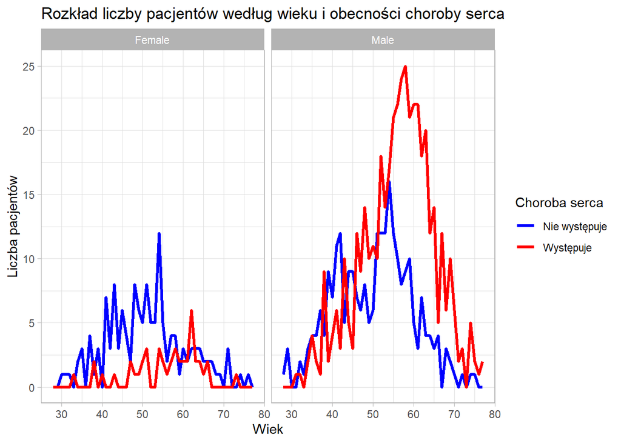

```r
ggplot(dane, aes(x = age, color = choroba, group = choroba)) +
  geom_line(stat = "bin", binwidth = 1, linewidth = 1.2) +
  scale_color_manual(values = c("blue", "red")) +
  labs(title = "Rozkład liczby pacjentów według wieku i obecności choroby serca",
       x = "Wiek",
       y = "Liczba pacjentów",
       color = "Choroba serca") +
  theme_light() +
  facet_wrap(~ sex)
```

Wyraźnie zauważalny jest wyższy stopień zachorowań u mężczyzn w starszym wieku, a u kobiet ryzyko wzrasta wraz z wiekiem, ale może być mniejsze do pewnego momentu. Z obliczeń wynika, że mężczyźni mogą być bardziej narażoną grupą.

# 5. Czy istnieje zależność pomiędzy poziomem cholesterolu a obecnością choroby serca?

## a) Podzielenie cholesterolu na cztery kategorie i wyznaczenie ilości obserwacji:

- **Niski poziom**: < 125 mg/dl
- **Prawidłowy poziom**: 125–200 mg/dl
- **Podwyższony poziom**: 200–239 mg/dl
- **Wysoki poziom**: ≥ 240 mg/dl

```r
dane <- dane %>%
  mutate(klasa_cholesterolu = case_when(
    chol < 125 ~ "Niski",
    chol >= 125 & chol <= 200 ~ "Normalny",
    chol > 200 & chol <= 239 ~ "Podwyższony",
    chol >= 240 ~ "Wysoki",
  ))

table(dane$klasa_cholesterolu, dane$num)
```

```
##
##                 0   1   2   3   4
##   Niski         1   2   0   0   0
##   Normalny     80  23   9  10   4
##   Podwyższony 122  57  20  20   6
##   Wysoki      200 173  78  71  15
```

## b) Statystyki opisowe

Pomiędzy cholesterolem a stopniami zaawanssowania choroby:

```r
statystyki_opisowe_chol <- dane %>%
  group_by(num) %>%
  summarise(
    Średnia = mean(chol, na.rm = TRUE),
    Mediana = median(chol, na.rm = TRUE),
    `Odchylenie standardowe` = sd(chol, na.rm = TRUE),
    Min = min(chol, na.rm = TRUE),
    Max = max(chol, na.rm = TRUE),
    Liczebność = n()
  )
knitr::kable(statystyki_opisowe_chol,
             caption = "Statystyki opisowe wyników poziomu cholesterolu w stopniach choroby")
```

Statystyki opisowe wyników poziomu cholesterolu w stopniach choroby

| num | Średnia | Mediana | Odchylenie standardowe | Min | Max | Liczebność |
| --- | --- | --- | --- | --- | --- | --- |
| 0 | 238.3387 | 239.0000 | 46.36575 | 100 | 394 | 403 |
| 1 | 248.7750 | 246.8329 | 42.28691 | 100 | 393 | 255 |
| 2 | 248.4593 | 246.8329 | 36.49289 | 153 | 384 | 107 |
| 3 | 248.4734 | 246.8329 | 40.65179 | 131 | 369 | 101 |
| 4 | 236.1532 | 246.8329 | 37.44600 | 166 | 304 | 25 |

- Zdrowi pacjenci mają najniższą medianę wartości cholesterolu w porównaniu do innych grup
- Poziom cholesterolu może być nieco wyższy w początkowych stadiach choroby, ale nie wykazuje silnego wzrostu w bardziej zaawansowanych grupach
- Grupa zdrowych charakteryzuje się największą zmiennością poziomu cholesterolu
- Ekstremalne wartości cholesterolu (bardzo niskie lub bardzo wysokie) są obecne zarówno wśród zdrowych, jak i chorych

## c) Wykres pudełkowy

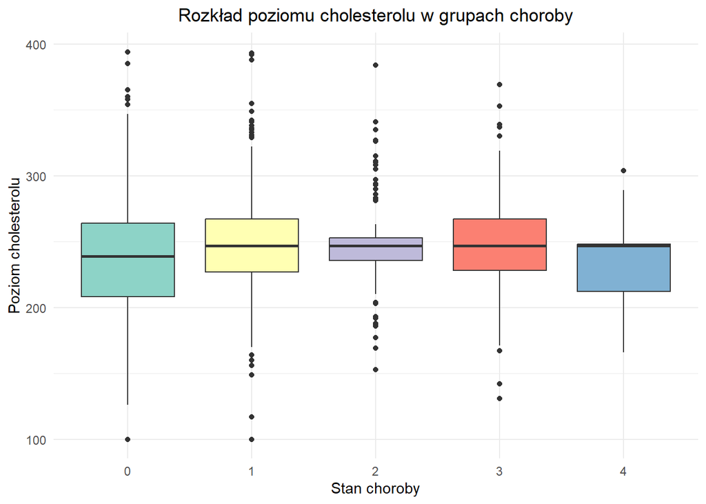

```r
ggplot(dane, aes(x = as.factor(num), y = chol, fill = as.factor(num))) +
  geom_boxplot() +
  labs(
    title = "Rozkład poziomu cholesterolu w grupach choroby",
    x = "Stan choroby",
    y = "Poziom cholesterolu",
    fill = "Stan choroby"
  ) +
  theme_minimal() +
  scale_fill_brewer(palette = "Set3") +
  theme(
    plot.title = element_text(hjust = 0.5),
    legend.position = "none"
  )
```

## d) Wykres słupkowy

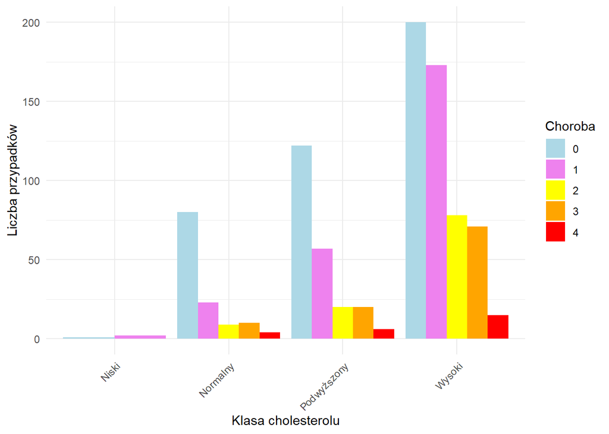

```r
ggplot(dane, aes(x = klasa_cholesterolu, fill = factor(num))) +
  geom_bar(position = "dodge") +
  labs(x = "Klasa cholesterolu", y = "Liczba przypadków", fill = "Choroba") +
  scale_fill_manual(values = c("lightblue", "violet", "yellow", "orange", "red")) +
  theme_minimal() +
  theme(axis.text.x = element_text(angle = 45, hjust = 1))
```

W tym zbiorze danych pacjenci z wysokim poziomem cholesterolu są widocznie bardziej narażeni na chorobę serca. Poziom cholesterolu może się przyczyniać do występowania choroby, ale nie jest jej głownym czynnikiem.

# 6. Co możemy wywnioskować z ciśnienia spoczynkowego a chorobą serca?

**Kwalifikacja ciśnienia spoczynkowego:**

- Niskie (hipotonia): <90/60
- Normalne: 90/60 – 120/80
- Podwyższone: 120/80 – 140/90
- Nadciśnienie: >140/90

## a) Sprawdzenie ilości obserwacji w różnych stadiach choroby:

```r
dane <- dane %>%
  mutate(klasa_cisnienia = case_when(
    trestbps < 90 ~ "Niskie",
    trestbps >= 90 & trestbps <= 120 ~ "Normalne",
    trestbps > 120 & trestbps <= 140 ~ "Podwyższone",
    trestbps > 140 ~ "Nadciśnienie",
    TRUE ~ NA_character_
  ))
table(dane$klasa_cisnienia, dane$num)
```

```
##
##                  0   1   2   3   4
##   Nadciśnienie  66  66  26  30   9
##   Niskie         1   0   0   0   0
##   Normalne     147  83  26  22   6
##   Podwyższone  189 106  55  49  10
```

## b) Statystyki opisowe

Pomiędzy ciśnieniem, a stopniami zaawansowania choroby:

```r
statystyki_opisowe_trestbps <- dane %>%
  group_by(num) %>%
  summarise(
    Średnia = mean(trestbps, na.rm = TRUE),
    Mediana = median(trestbps, na.rm = TRUE),
    `Odchylenie standardowe` = sd(trestbps, na.rm = TRUE),
    Min = min(trestbps, na.rm = TRUE),
    Max = max(trestbps, na.rm = TRUE),
    Liczebność = n()
  )
knitr::kable(statystyki_opisowe_trestbps,
             caption = "Statystyki opisowe wyników poziomu ciśnienia w stopnioch choroby")
```

Statystyki opisowe wyników poziomu ciśnienia w stopnioch choroby

| num | Średnia | Mediana | Odchylenie standardowe | Min | Max | Liczebność |
| --- | --- | --- | --- | --- | --- | --- |
| 0 | 129.6725 | 130 | 16.07885 | 80 | 180 | 403 |
| 1 | 132.3569 | 130 | 18.73904 | 92 | 185 | 255 |
| 2 | 133.2804 | 130 | 16.81295 | 95 | 180 | 107 |
| 3 | 134.3395 | 130 | 15.82634 | 100 | 180 | 101 |
| 4 | 136.1600 | 130 | 18.83852 | 104 | 170 | 25 |

- Średnia wartość ciśnienia wzrasta wraz ze wzrostem zaawansowania choroby
- Mediana ciśnienia jest względnie stała w różnych grupach
- Odchylenie standardowe jest najwyższe w stopniu 4 choroby (18.84), co sugeruje większą zmienność poziomu ciśnienia w tej grupie
- Grupa zdrowych jest najliczniejsza (403), podczas gdy grupa z najbardziej zaawansowaną chorobą ma tylko 25 pacjentów

## c) Wykres pudełkowy

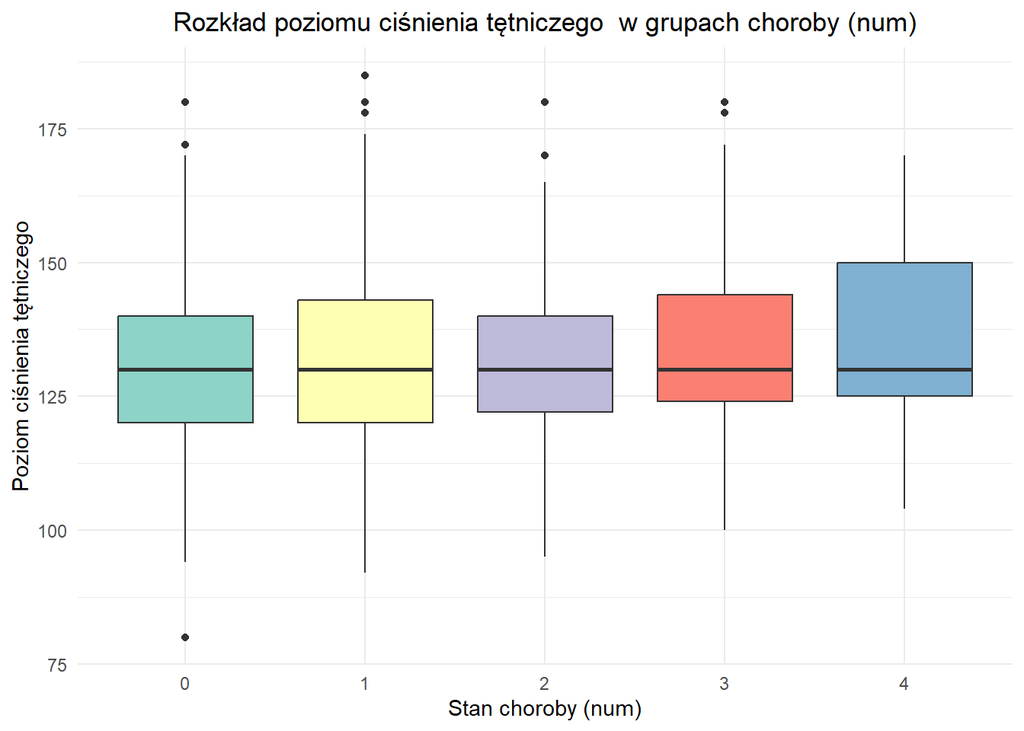

```r
ggplot(dane, aes(x = as.factor(num), y = trestbps, fill = as.factor(num))) +
  geom_boxplot() +
  labs(
    title = "Rozkład poziomu ciśnienia tętniczego  w grupach choroby (num)",
    x = "Stan choroby (num)",
    y = "Poziom ciśnienia tętniczego",
    fill = "Stan choroby"
  ) +
  theme_minimal() +
  scale_fill_brewer(palette = "Set3") +
  theme(
    plot.title = element_text(hjust = 0.5),
    legend.position = "none"
  )
```

## d) Wykres słupkowy

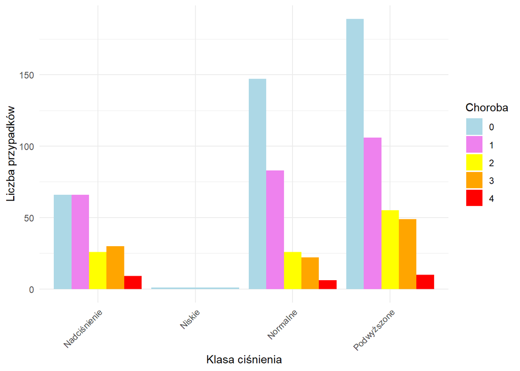

```r
ggplot(dane, aes(x = klasa_cisnienia, fill = factor(num))) +
  geom_bar(position = "dodge") +
  labs(x = "Klasa ciśnienia", y = "Liczba przypadków", fill = "Choroba") +
  scale_fill_manual(values = c("lightblue", "violet", "yellow", "orange", "red")) +
  theme_minimal() +
  theme(axis.text.x = element_text(angle = 45, hjust = 1))
```

Podsumowując nadciśnienie jest silnie związane z wyższym ryzykiem wystąpienia choroby serca. Poziom ciśnienia tętniczego wydaje się wzrastać wraz z pogarszającym się stanem zdrowia pacjentów

# 7. Czy można coś wywnioskować po rodzaju bólu klatki piersiowej?

## a) Sprawdzenie ilości obserwacjii

```r
table(dane$cp, dane$num)
```

```
##
##                     0   1   2   3   4
##   asymptomatic    101 189  87  78  20
##   atypical angina 148  18   2   3   0
##   non-anginal     129  36  14  17   4
##   typical angina   25  12   4   3   1
```

## b) Wykres słupkowy

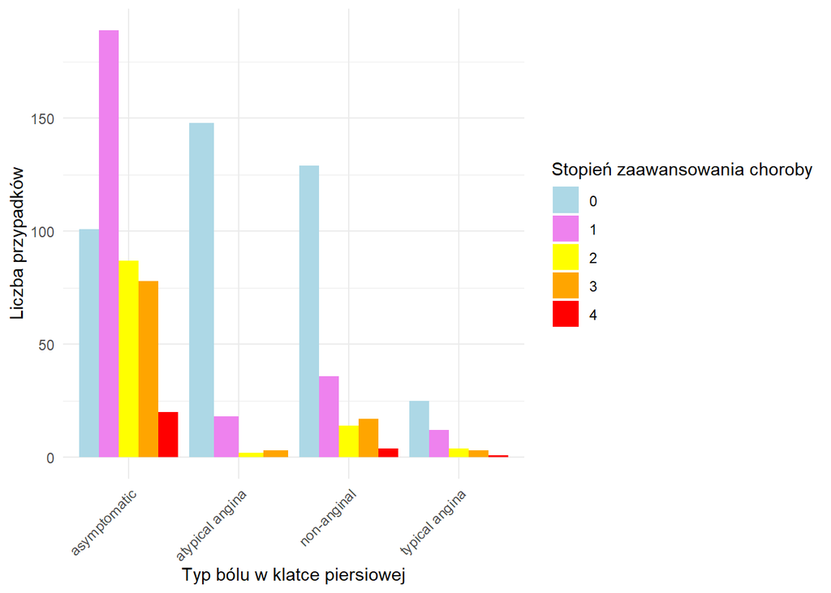

```r
ggplot(dane, aes(x = cp, fill = factor(num))) +
  geom_bar(position = "dodge") +
  labs(x = "Typ bólu w klatce piersiowej", y = "Liczba przypadków", fill = "Stopień zaawansowania choroby") +
  scale_fill_manual(values = c("lightblue", "violet", "yellow", "orange", "red")) +
  theme_minimal() +
  theme(axis.text.x = element_text(angle = 45, hjust = 1))
```

W grupie bólu bezobjawowego widać wysoką liczbę przypadków, które wykazują zaawansowanie choroby, co może wskazywać, że osoby z bezobjawowym bólem serca często mogą mieć chorobę serca, która nie jest odczuwana w sposób tradycyjny. Również występuje większa liczba przypadków w grupie bólu niezwiązanego z dławicą. Podsumowując ciężko przewidzieć chorobę po samym rodzaju bólu klatki piersiowej, gdyż duża część chorych pacjentów nie odczuwa bólu.

# 8. Jak możemy interpretowawć poziom cukru we krwi a obecnością choroby serca?

## a) Sprawdzenie ilości obserwacji

```r
table(dane$fbs, dane$choroba)
```

```
##
##         Nie występuje Występuje
##   FALSE           361       397
##   TRUE             42        91
```

## b) Test zależności

```r
chisq.test(table(dane$fbs, dane$choroba))
```

```
##
##  Pearson's Chi-squared test with Yates' continuity correction
##
## data:  table(dane$fbs, dane$choroba)
## X-squared = 11.122, df = 1, p-value = 0.0008532
```

Wynik testu chi-kwadrat wskazuje na statystycznie istotną zależność pomiędzy poziomem cukru a stopniem zaawansowania choroby. P-value Jest mniejsze od typowego progu istotności 0.05, co oznacza, że możemy odrzucić hipotezę zerową (H₀ = nie ma związku pomiędzy poziomem cukru we krwi a chorobą)

## c) Tworzenie wykresu kołowego dla wizualizacji zmiennych

Przekształcenie tabeli do formatu odpowiedniego dla wykresu - procentowy udział w każdej kategorii cukru.

```r
tabela_fbs <- table(dane$fbs, dane$choroba)

tabela_fbs_procent <- prop.table(tabela_fbs, 1)

tabela_fbs_df <- as.data.frame(tabela_fbs_procent)
colnames(tabela_fbs_df) <- c("Poziom_cukru", "Choroba", "Procent")
```

Wykresy kołowe:

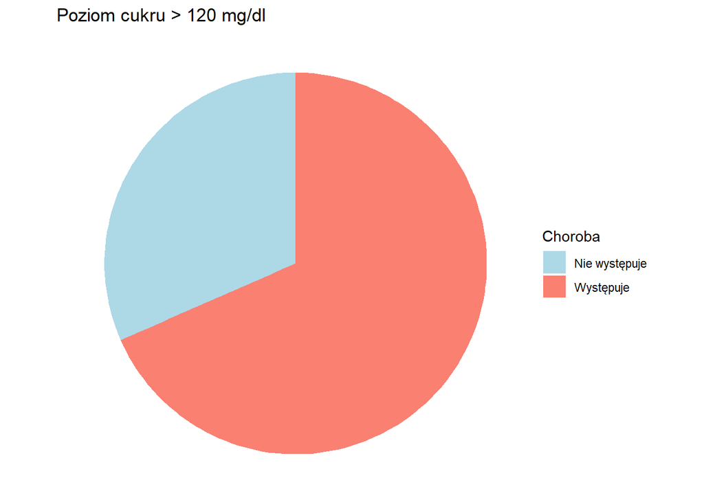

```r
ggplot(subset(tabela_fbs_df, Poziom_cukru == "TRUE"), aes(x = "", y = Procent, fill = factor(Choroba))) +
  geom_bar(stat = "identity", width = 1) +
  coord_polar(theta = "y") +
  labs(title = "Poziom cukru > 120 mg/dl", fill = "Choroba") +
  scale_fill_manual(values = c("lightblue", "salmon")) +
  theme_void() +
  theme(axis.text.x = element_blank())
```

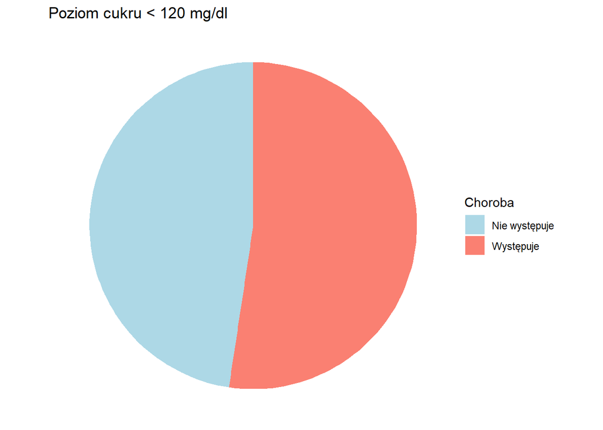

```r
ggplot(subset(tabela_fbs_df, Poziom_cukru == "FALSE"), aes(x = "", y = Procent, fill = factor(Choroba))) +
  geom_bar(stat = "identity", width = 1) +
  coord_polar(theta = "y") +
  labs(title = "Poziom cukru < 120 mg/dl", fill = "Choroba") +
  scale_fill_manual(values = c("lightblue", "salmon")) +
  theme_void() +
  theme(axis.text.x = element_blank())
```

Podsumowując, choć liczba osób z wysokim poziomem cukru jest mniejsza, to ich odsetek chorujących jest wyższy. Wyższy poziom cukru we krwi może przyczyniać się do choroby serca.

# 9. Jak wyniki depresji odcinka ST wpływają na obecnośc choroby serca?

## a) Sprawdzenie ilości obserwacji

```r
table(dane$oldpeak, dane$choroba)
```

```
##
##        Nie występuje Występuje
##   -2               0         1
##   -1.5             0         1
##   -1.1             1         0
##   -1               0         2
##   -0.9             0         1
##   -0.8             0         1
##   -0.7             0         1
##   -0.5             1         1
##   -0.1             1         0
##   0              241       119
##   0.1              4         5
##   0.2             10         4
##   0.3              2         3
##   0.4              8         2
##   0.5             28        53
##   0.6             10         4
##   0.7              2         3
##   0.8              7         7
##   0.9              1         3
##   1               25        54
##   1.1              2         2
##   1.2              7        10
##   1.3              2         3
##   1.4              6         9
##   1.5             11        37
##   1.6              7         6
##   1.7              0         2
##   1.8              3         9
##   1.9              2         2
##   2               14        59
##   2.1              0         2
##   2.2              0         5
##   2.3              2         0
##   2.4              1         3
##   2.5              0        16
##   2.6              1         6
##   2.8              0         7
##   2.9              0         1
##   3                3        25
##   3.1              0         1
##   3.2              0         2
##   3.4              0         3
##   3.5              1         1
##   3.6              0         4
##   3.7              0         1
##   3.8              0         1
##   4                0         6
```

## b) Statystyki opisowe

Pomiędzy odcinkem ST, a stopniami zaawansowania choroby

```r
statystyki_opisowe_ST <- dane %>%
  group_by(num) %>%
  summarise(
    Średnia = mean(oldpeak, na.rm = TRUE),
    Mediana = median(oldpeak, na.rm = TRUE),
    `Odchylenie standardowe` = sd(oldpeak, na.rm = TRUE),
    Min = min(oldpeak, na.rm = TRUE),
    Max = max(oldpeak, na.rm = TRUE),
    Liczebność = n()
  )

knitr::kable(statystyki_opisowe_ST,
             caption = "Statystyki opisowe depresji ST w stopnioch choroby")
```

Statystyki opisowe depresji ST w stopnioch choroby

| num | Średnia | Mediana | Odchylenie standardowe | Min | Max | Liczebność |
| --- | --- | --- | --- | --- | --- | --- |
| 0 | 0.4119107 | 0.0 | 0.6737118 | -1.1 | 3.5 | 403 |
| 1 | 0.9780392 | 1.0 | 0.9631335 | -1.5 | 4.0 | 255 |
| 2 | 1.2971963 | 1.4 | 1.1882648 | -2.0 | 4.0 | 107 |
| 3 | 1.2960396 | 1.0 | 1.0755390 | 0.0 | 4.0 | 101 |
| 4 | 2.0240000 | 2.4 | 1.2868825 | 0.0 | 4.0 | 25 |

## c) Wykres pudełkowy

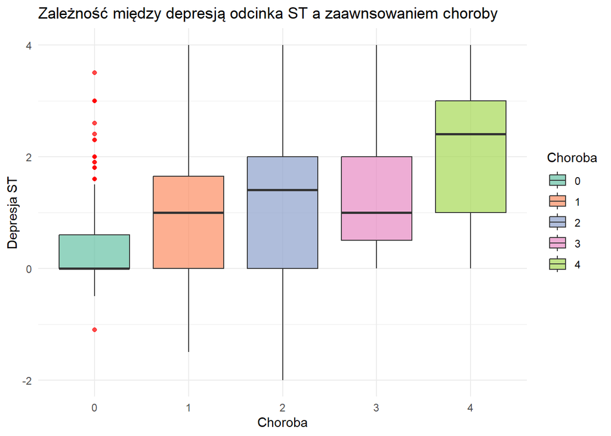

```r
ggplot(dane, aes(x = as.factor(num), y = oldpeak, fill = as.factor(num))) +
  geom_boxplot(alpha = 0.7, outlier.color = "red") +
  scale_fill_brewer(palette = "Set2") +
  labs(
    x = "Choroba",
    y = "Depresja ST",
    title = "Zależność między depresją odcinka ST a zaawnsowaniem choroby",
    fill = "Choroba"
  ) +
  theme_minimal()
```

Podsumowując czym wyższa jest wartośc depresji odcinka ST tym wyższe są odnotowywane stopnie zaawansowania choroby serca.

# 10. Jak wyniki testu wysiłkowego zależały od stopnia zaawansowania choroby?

## a) Statystyki opisowe

```r
statystyki_opisawe_thalch <- dane %>%
  group_by(num) %>%
  summarise(
    Średnia = mean(thalch, na.rm = TRUE),
    Mediana = median(thalch, na.rm = TRUE),
    Odchylenie_standardowe = sd(thalch, na.rm = TRUE),
    Min = min(thalch, na.rm = TRUE),
    Max = max(thalch, na.rm = TRUE),
    Liczebność = n()
  )

knitr::kable(statystyki_opisawe_thalch,
             caption = "Statystyki opisowe testu wysiłkowego w stopnioch choroby")
```

Statystyki opisowe testu wysiłkowego w stopnioch choroby

| num | Średnia | Mediana | Odchylenie_standardowe | Min | Max | Liczebność |
| --- | --- | --- | --- | --- | --- | --- |
| 0 | 148.6526 | 150 | 22.82888 | 80 | 202 | 403 |
| 1 | 131.1176 | 130 | 22.93748 | 72 | 182 | 255 |
| 2 | 129.8505 | 130 | 21.31029 | 71 | 180 | 107 |
| 3 | 123.0297 | 122 | 24.81268 | 63 | 173 | 101 |
| 4 | 126.4000 | 125 | 23.50000 | 84 | 182 | 25 |

## b) Wykres pudełkowy

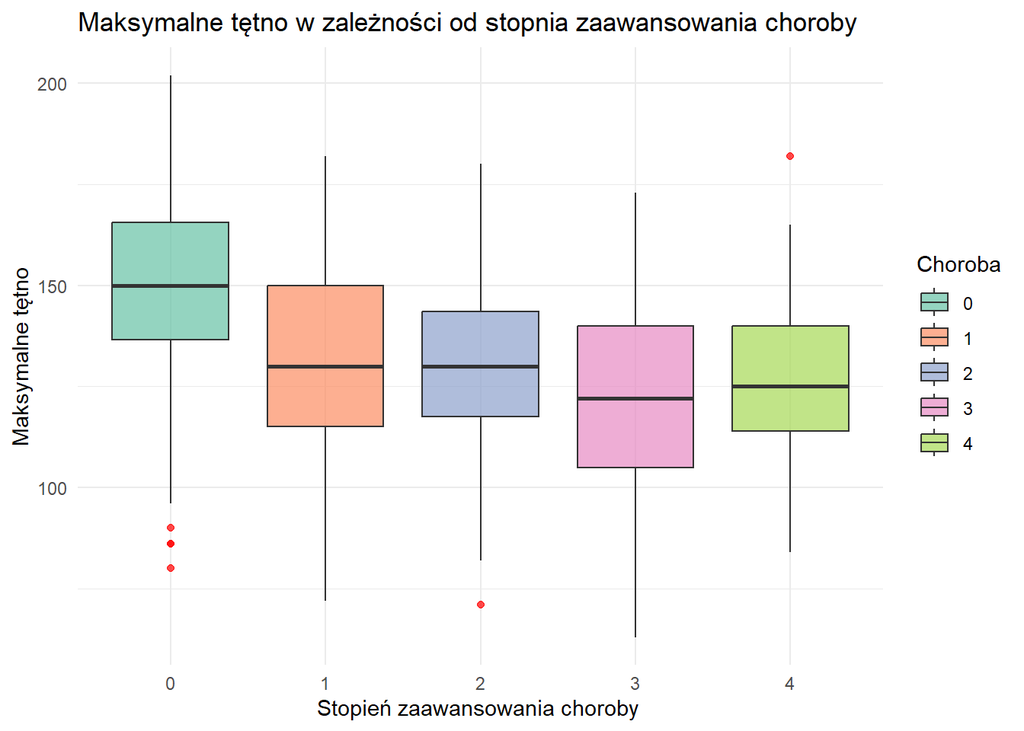

```r
ggplot(dane, aes(x = as.factor(num), y = thalch, fill = as.factor(num))) +
  geom_boxplot(alpha = 0.7, outlier.color = "red") +
  scale_fill_brewer(palette = "Set2") +
  labs(
    x = "Stopień zaawansowania choroby ",
    y = "Maksymalne tętno",
    title = "Maksymalne tętno w zależności od stopnia zaawansowania choroby",
    fill = "Choroba"
  ) +
  theme_minimal()
```

Chorzy pacjenci mają niższe tętno podczas wysiłku niż zdrowi, co jasno wskazuje wpływ choroby na wyniki.

## c) Zbadanie występowania dławicy piersiowej wywołanej wysiłkiem fizycznym u chorych pacjentów

Obliczenie procentu odnotowawnych przypadków:

```r
table_chory_angina <- table(dane$num, dane$exang)
table_chory_angina
```

```
##
##     FALSE TRUE
##   0   348   55
##   1   115  140
##   2    50   57
##   3    41   60
##   4    11   14
```

```r
prop.table(table_chory_angina, margin = 1) * 100
```

```
##
##        FALSE     TRUE
##   0 86.35236 13.64764
##   1 45.09804 54.90196
##   2 46.72897 53.27103
##   3 40.59406 59.40594
##   4 44.00000 56.00000
```

Wizualizacja:

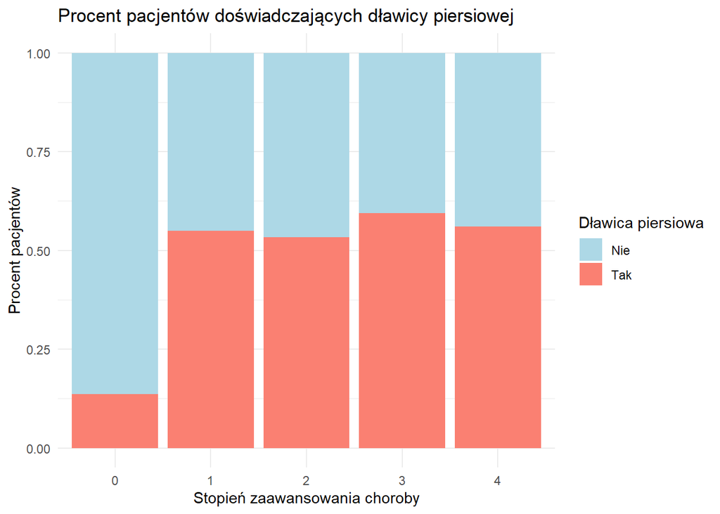

```r
ggplot(dane, aes(x = as.factor(num), fill = exang)) +
  geom_bar(position = "fill") +
  labs(title = "Procent pacjentów doświadczających dławicy piersiowej",
       x = "Stopień zaawansowania choroby",
       y = "Procent pacjentów",
       fill = "Dławica piersiowa") +
  scale_fill_manual(values = c("lightblue", "salmon"),
                    labels = c("Nie", "Tak")) +
  theme_minimal()
```

# 11. Co można wywnioskować z wyników EKG?

## a) Sprawdzenie ilości obserwacji

```r
table(dane$restecg, dane$num)
```

```
##
##                      0   1   2   3   4
##   lv hypertrophy    79  44  21  24  11
##   normal           263 165  54  47   8
##   st-t abnormality  61  46  32  30   6
```

## b) Procentowy podział

```r
prop.table(table(dane$restecg, dane$num), 2) * 100
```

```
##
##                           0        1        2        3        4
##   lv hypertrophy   19.60298 17.25490 19.62617 23.76238 44.00000
##   normal           65.26055 64.70588 50.46729 46.53465 32.00000
##   st-t abnormality 15.13648 18.03922 29.90654 29.70297 24.00000
```

W grupie zdrowej oraz w pierwszym, drugim i trzecim stadium choroby najwięcej pacjentów miało wynik normalny, ale w grupie z najbardziej zaawansowaną chorobą w prawie połowie przypadków wystąpił przerost lewej komory serca. Odsetek pacjentów z wynikiem normlanym zmniejsza się wraz z rozwojem choroby.

## c) Test Chi-kwadrat

```r
chisq.test(table(dane$restecg, dane$num))
```

```
##
##  Pearson's Chi-squared test
##
## data:  table(dane$restecg, dane$num)
## X-squared = 35.238, df = 8, p-value = 2.42e-05
```

Wynik testu chi-kwadrat wskazuje na statystycznie istotną zależność pomiędzy wynikiem badania EKG a stopniem zaawansowania choroby. P-value Jest znacznie mniejsze od typowego progu istotności 0.05, co oznacza, że możemy odrzucić hipotezę zerową (H₀ = nie ma związku między wynikiem EKG a chorobą)

## d) Wizualizacja

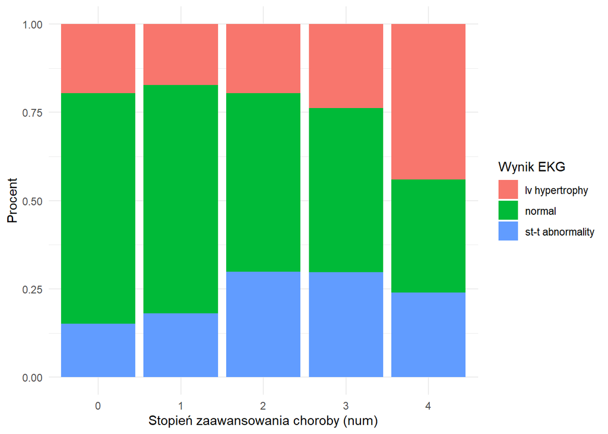

```r
ggplot(dane, aes(x = as.factor(num), fill = restecg)) +
  geom_bar(position = "fill") +
  labs(x = "Stopień zaawansowania choroby (num)", y = "Procent", fill = "Wynik EKG") +
  theme_minimal()
```

Wraz ze wzrostem stopnia zaawansowania chroby zwiększa się ilośc obserwacji przerostu lewej komory serca i nietypowego wyniku.

# 12. Z którego regionu wśród badanych zaobserwowana najwięcej chorych w bardziej zaawansowanym stadium choroby? (ze stadium 3 i 4)

## a) Sprawdzenie ilości obserwacji

Sprawdzam ile osób zbadano w każdym regione, aby sprawdzić czy wyniki nie będą zaburzone

```r
dane$dataset <- as.factor(dane$dataset)
class(dane$dataset)
```

```
## [1] "factor"
```

```r
table(dane$dataset)
```

```
##
##     Cleveland       Hungary   Switzerland VA Long Beach
##           293           281           119           198
```

Najwięcej pacjentów pochodzi z Cleveland i Węgier, co może wpływac na wyniki, a najmniej w Szwajcarii

## b) Ilość chorych pacjentów

```r
table(dane$dataset, dane$num)
```

```
##
##                   0   1   2   3   4
##   Cleveland     162  54  35  31  11
##   Hungary       183  98   0   0   0
##   Switzerland     8  47  31  28   5
##   VA Long Beach  50  56  41  42   9
```

## c) Wizualizacja

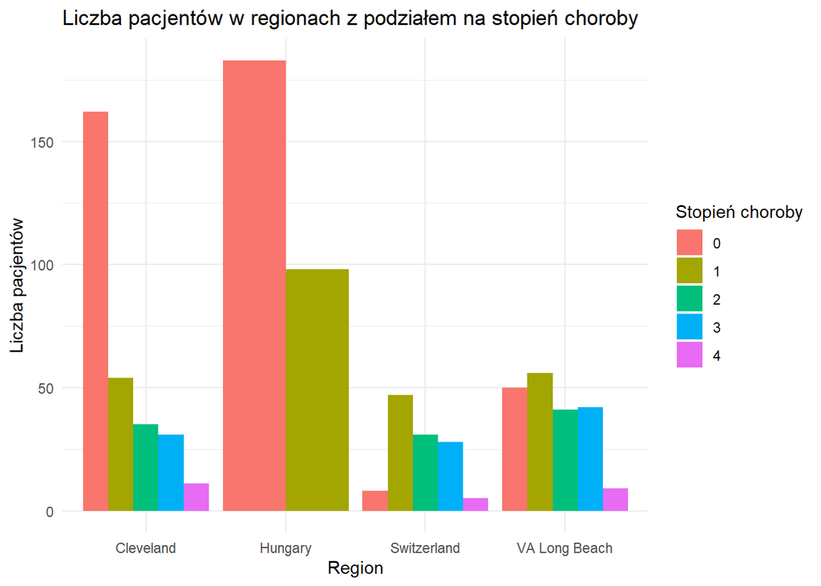

```r
ggplot(dane, aes(x = dataset, fill = as.factor(num))) +
  geom_bar(position = "dodge") +
  labs(
    x = "Region",
    y = "Liczba pacjentów",
    fill = "Stopień choroby",
    title = "Liczba pacjentów w regionach z podziałem na stopień choroby"
  ) +
  theme_minimal()
```

# Podsumowanie

**Zależność między wiekiem a chorobą serca**

- Ryzyko zachorowania wzrasta po 55 roku życia.
- Pacjenci w najstarszej grupie wiekowej byli najbardziej narażeni.

**Płeć a ryzyko choroby**

- Mężczyźni byli bardziej narażeni niż kobiety.
- Test chi-kwadrat wykazał istotną statystycznie różnicę w ryzyku między płciami.

**Wpływ cholesterolu**

**Ciśnienie spoczynkowe**

- Nadciśnienie znacząco zwiększało ryzyko choroby serca.

**Typ bólu w klatce piersiowej**

- Grupa bezobjawowa była najczęściej związana z zaawansowanymi przypadkami choroby. Po samym rodzaju odczuwanego bólu ciężko wysunąć wnioski, gdyż większość chorych go nie odczuwała.

**Poziom cukru we krwi**

- Podwyższony poziom cukru miał istotną zależność z występowaniem choroby serca.

**Depresja odcinka ST**

- Wzrost wartości depresji ST był silnie związany z bardziej zaawansowanymi stadiów choroby serca

**Wyniki testu wysiłku fizycznego**

- Wyraźnie widać, że pacjenci z bardziej zaawansowaną chorobą serca mają niższe wyniki w teście wysiłkowym
- Chorzy doświadczają znacznie częsciej dławicy piersiowej wywołanej wysiłkiem fizycznym niż zdrowi